# Limpeza de Dados

Nicholas A. C. Marino

nac.marino@gmail.com

github.com/nacmarino/flashR

## Elementos da Aula

1. A natureza dos dados - Parte 2
2. Entendendo o conteúdo de uma tabela
3. Editando as informações de um conjunto de dados
4. Coerção de vetores e colunas
5. Exercícios
   - Exercício 1
   - Exercício 2
   - Exercício 3
   - Exercício 4
   - Exercício 5
   - Exercício 6

## 1. A natureza dos dados - Parte 2

- Conforme vimos na última aula, a manipulação de um conjunto de dados para facilitar o seu uso pode ser feito facilmente no R.
- Associado a isto, está o fato de que muitas vezes não podemos utilizar assim tão diretamente um conjunto de dados, por inúmeros motivos:
  - Erros de digitação;
  - Erros de codificação;
  - Um ‘tipo’ de informação está espalhada em várias colunas;
  - Um ‘tipo’ de informação está em uma única coluna;
  - Um ‘tipo’ de informação precisa ser derivada a partir de uma ou mais colunas;
  - …
- O problema é que só percebemos muitas destas coisas quando estamos mexendo com os dados, e depois de já termos feito vários tipos de manipulações com os mesmos;
- Além disso, muitas detectamos alguns destes problemas antes mesmo de manipularmos um conjunto de dados; todavia, a constante adição de novos dados faz com que tenhamos que consertar e resolver estes problemas muitas e muitas vezes de forma manual.
- A ideia aqui é demonstrar maneiras de fazer todos esses ‘consertos’ de forma rápida, reprodutível e sem mistérios.

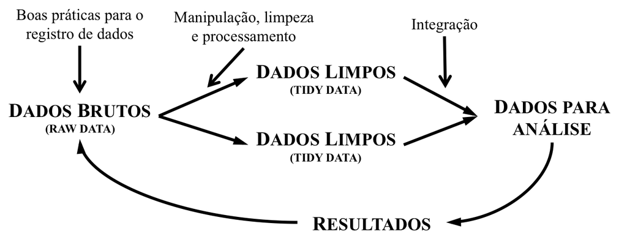

### Exercício 1

1. Importe os conjuntos de dados que contenham os dados dos projetos financiados pelo CNPq, as informações das publicações que se originaram a partir destes projetos, e as informações das revistas onde estes trabalhos foram publicados e dos autores de cada um dos trabalhos publicados (`dados dos projetos.csv`, `publicacoes.xlsx` e `revistas.xlsx`, `autores.xls`). Atribua cada um destes arquivos a um objeto.

## 2. Entendendo o conteúdo de uma tabela

- Muitas vezes temos um conjunto de dados muito grande e não temos noção do que podemos encontrar em cada uma das colunas. Outras vezes, queremos fazer uma ou outra análise, mas não sabemos exatamente quantas observações temos para cada um dos níveis de um fator ou, ainda, se existe ortogonalidade entre dois ou mais fatores. Para tal, podemos utilizar as funções `table` e `unique`para aprender um pouco mais sobre um conjunto de dados que estamos trabalhando.
- A função `table` é útil pois ela constrói tabelas de contingência baseadas em um ou mais níveis de um conjunto de dados. Nos exemplos abaixo, exploramos quantas observações temos referentes a cada um dos sexos dos pesquisadores, bem como a região no qual estão e o tipo de bolsa de produtividade que possuem.

```r
# número de observações pertencentes a cada um dos níveis da variável sexo
table(projetos$sexo)
```

```
##
##  F  M
## 36 83
```

```r
# número de observações pertencentes a cada um dos níveis da variável bolsa de produtividade
table(projetos$produtividade)
```

```
##
##  1A  1B  1C  1D   2 Nao  SR
##  18   7   5  16  29  43   1
```

```r
# combinando as duas últimas variáveis
table(projetos$produtividade, projetos$sexo)
```

```
##
##        F  M
##   1A   0 18
##   1B   4  3
##   1C   2  3
##   1D   7  9
##   2    4 25
##   Nao 19 24
##   SR   0  1
```

```r
# adicionando uma terceira variável
table(projetos$regiao, projetos$produtividade, projetos$sexo)
```

```
## , ,  = F
##
##
##      1A 1B 1C 1D 2 Nao SR
##   CO  0  0  0  1 2   2  0
##   NE  0  1  0  1 1   4  0
##   NO  0  0  0  4 0   4  0
##   SE  0  1  1  1 0   4  0
##   SU  0  2  1  0 1   5  0
##
## , ,  = M
##
##
##      1A 1B 1C 1D 2 Nao SR
##   CO  2  0  1  1 5   4  0
##   NE  2  1  0  0 5   1  0
##   NO  2  0  0  0 2   6  0
##   SE  9  2  2  5 7   6  1
##   SU  3  0  0  3 6   7  0
```

- No exemplo abaixo, utilizamos a função `unique` para termos uma noção de quais são os valores únicos que aparecem dentro da coluna **Chamada** do objeto **projetos** - você consegue encontrar algum erro em algum dos elementos?

```r
unique(x = projetos$Chamada)
```

```
##  [1] "Universal - Faixa A"             "BJT"
##  [3] "Universal - Faixa C"             "Incubadoras"
##  [5] "PPBio - Rede Mata Atletica"      "Universal - Faixa B"
##  [7] "PVE"                             "Linha 1 - Faixa - B"
##  [9] "PPBio - Rede Amazonia Ocidental" "Linha 1: Universidades"
## [11] "Pesca"                           "PELD"
## [13] "PPBio - Rede Cerrado"            "PPBio - Rede Campos Sulinos"
## [15] "Alemanha DFG"                    "GEOMA - Rede GEOMA"
## [17] "Ilhas Oceanicas"                 "PV"
## [19] "Argentina - CNPq/CONICET"        "Belgica"
## [21] "CsF"
```

- Este tipo de exercício é muito útil para encontrarmos erros de digitação e também palavras que parecem duplicadas por conta de erros como esse. Por exemplo, compare o tamanho do vetor que contém o nome dos autores antes e depois de excluirmos as duplicatas. Será que se você olhar rapidamente estes dois vetores, você enxerga duplicatas que não foram removidas pois o mesmo nome está grafado de forma diferente?

```r
# todos os nomes
length(x = autores$nome)
```

```
## [1] 4594
```

```r
# excluindo duplicatas que dão para ser excluídas no momento
length(x = unique(x = autores$nome))
```

```
## [1] 3109
```

- Podemos também remover entradas duplicatas de uma tabela inteira de forma bem fácil, através da função `distinct` disponível no pacote `dplyr` - que pode ser carregada através do `tidyverse`.

```r
library(tidyverse)
distinct(.data = projetos, id_coordenador, .keep_all = TRUE)
```

```
## # A tibble: 111 x 26
##    Processo Chamada id_coordenador sexo  inicio termino instituicao uf
##       <dbl> <chr>            <int> <chr> <chr>  <chr>   <chr>       <chr>
##  1  4.86e10 Univer~              1 M     06/11~ 05/11/~ FURG        RS
##  2  4.01e10 BJT                  2 F     12/09~ 11/09/~ UFSCAR      SP
##  3  4.82e10 Univer~              3 M     08/11~ 30/11/~ UFPR-PRPG   PR
##  4  4.72e10 Univer~              4 F     14/12~ 31/12/~ UFRPE       PE
##  5  4.76e10 Univer~              5 M     30/10~ 31/10/~ UFPB        PB
##  6  4.82e10 Univer~              6 M     07/05~ 05/05/~ INPA        AM
##  7  4.80e10 Univer~              7 M     19/11~ 18/11/~ INPA        AM
##  8  4.46e10 Incuba~              8 M     02/08~ 31/12/~ PUC GOIAS   GO
##  9  4.58e10 PPBio ~              9 M     12/12~ 11/12/~ UFRJ        RJ
## 10  4.72e10 Univer~             10 M     28/11~ 30/11/~ UERJ        RJ
## # ... with 101 more rows, and 18 more variables: cidade <chr>,
## #   regiao <chr>, duracao <int>, brasileiro <chr>, produtividade <chr>,
## #   doutorado <int>, doutorado_exterior <chr>, sanduiche <chr>,
## #   posdoc <chr>, indiceH <int>, bolsa_contratado <dbl>,
## #   bolsa_gasto <int>, capital_contratado <dbl>, capital_gasto <dbl>,
## #   custeio_contratado <dbl>, custeio_gasto <dbl>, total_fornecido <dbl>,
## #   total_gasto <dbl>
```

- Por vezes, para facilitar a busca de uma palavra em um grande conjunto de dados podemos utilizar a função `grep` ou `grepl`.
  - `grep` retorna as **posições** que contém o padrão buscado;
  - `grepl` faz um teste lógico no vetor testado e te indica com um `TRUE` os elementos desse vetor que contém o padrão buscado.

```r
# posições
grep(pattern = "Del-Claro", x = autores$nome)
# teste lógico
grepl(pattern = "Del-Claro", x = autores$nome)
```

- Podemos utilizar estas informações para detectar quantas formas diferentes existem em um conjunto de dados para se referir a uma mesma observação.

```r
autores[grep(pattern = "Del-Claro", x = autores$nome),]
```

```
## # A tibble: 9 x 3
##      Processo    id nome
##         <dbl> <dbl> <chr>
## 1 40060020137   572 Kleber Del-Claro
## 2 40060020137   573 Kleber Del-Claro
## 3 40060020137   574 Kleber Del-Claro
## 4 40060020137   575 Kleber Del-Claro
## 5 40060020137   576 Kleber Del-Claro
## 6 40060020137   577 K. Del-Claro
## 7 40060020137   699 Kleber Del-Claro
## 8 40060020137   704 Kleber Del-Claro
## 9          NA   578 Kleber Del-Claro
```

### Exercício 2

1. Quantas pessoas diferentes com o sobrenome **Silva** existem na lista de autores?
2. Quantas pessoas diferentes com seu sobrenome existem na lista de autores?

## 3. Editando as informações de um conjunto de dados

- Muito frequentemente precisaremos corrigir erros de digitação, palavras inteiras e até mesmo valores específicos em uma tabela.
- Duas funções bastante úteis para estes objetivos são `sub` e `gsub`, que detectam um padrão e o substituem por outra coisa qualquer que você determine - ou seja, bastante similar ao *Substituir* do Excel.

```r
# criando um vetor com três nomes
foo <- c("AmErica do NortE", "Oceania", "Asia")
foo
```

```
## [1] "AmErica do NortE" "Oceania"          "Asia"
```

```r
# substitui apenas a primeira ocorrência em cada elemento de que coincida com um padrão
sub(pattern = "E", replacement = "e", x = foo)
```

```
## [1] "America do NortE" "Oceania"          "Asia"
```

```r
# substitui todas as ocorrências em cada elemento que coincida com um padrão
gsub(pattern = "E", replacement = "e", x = foo)
```

```
## [1] "America do Norte" "Oceania"          "Asia"
```

- É preciso que você reescreva o objeto `x` para que essa edição tenha efeito.

```r
foo <- gsub(pattern = "E", replacement = "e", x = foo)
foo
```

```
## [1] "America do Norte" "Oceania"          "Asia"
```

- Podemos aplicar este tipo de substituição por padrões diretamente em uma tabela, associando o `sub` ou `gsub` ao `mutate`.

```r
# consertando um nome
autores <- autores %>%
  mutate(nome = sub(pattern = "Kleber", replacement = "K.", x = nome),
         nome = sub(pattern = "Del-Claro", replacement = "Del Claro", x = nome))
# buscando esse nome
autores[grep(pattern = "Del Claro", x = autores$nome),]
```

```
## # A tibble: 9 x 3
##      Processo    id nome
##         <dbl> <dbl> <chr>
## 1 40060020137   572 K. Del Claro
## 2 40060020137   573 K. Del Claro
## 3 40060020137   574 K. Del Claro
## 4 40060020137   575 K. Del Claro
## 5 40060020137   576 K. Del Claro
## 6 40060020137   577 K. Del Claro
## 7 40060020137   699 K. Del Claro
## 8 40060020137   704 K. Del Claro
## 9          NA   578 K. Del Claro
```

### Exercício 3

1. Substitua o erro de digitação que nós encontramos na coluna **Chamada** do objeto que contém os dados dos projetos, de forma que este conserto seja permanente neste conjunto de dados
- Podemos também editar os valores de uma coluna através de testes lógicos, utilizando a função `ifelse`.

```r
# a coluna 'sexo' do objeto projetos é representa por M, para masculino, ou F, para feminino
projetos
```

```
## # A tibble: 119 x 26
##    Processo Chamada id_coordenador sexo  inicio termino instituicao uf
##       <dbl> <chr>            <int> <chr> <chr>  <chr>   <chr>       <chr>
##  1  4.86e10 Univer~              1 M     06/11~ 05/11/~ FURG        RS
##  2  4.01e10 BJT                  2 F     12/09~ 11/09/~ UFSCAR      SP
##  3  4.82e10 Univer~              3 M     08/11~ 30/11/~ UFPR-PRPG   PR
##  4  4.72e10 Univer~              4 F     14/12~ 31/12/~ UFRPE       PE
##  5  4.76e10 Univer~              5 M     30/10~ 31/10/~ UFPB        PB
##  6  4.82e10 Univer~              6 M     07/05~ 05/05/~ INPA        AM
##  7  4.80e10 Univer~              7 M     19/11~ 18/11/~ INPA        AM
##  8  4.46e10 Incuba~              8 M     02/08~ 31/12/~ PUC GOIAS   GO
##  9  4.58e10 PPBio ~              9 M     12/12~ 11/12/~ UFRJ        RJ
## 10  4.72e10 Univer~             10 M     28/11~ 30/11/~ UERJ        RJ
## # ... with 109 more rows, and 18 more variables: cidade <chr>,
## #   regiao <chr>, duracao <int>, brasileiro <chr>, produtividade <chr>,
## #   doutorado <int>, doutorado_exterior <chr>, sanduiche <chr>,
## #   posdoc <chr>, indiceH <int>, bolsa_contratado <dbl>,
## #   bolsa_gasto <int>, capital_contratado <dbl>, capital_gasto <dbl>,
## #   custeio_contratado <dbl>, custeio_gasto <dbl>, total_fornecido <dbl>,
## #   total_gasto <dbl>
```

```r
## substituindo
projetos <- projetos %>%
  mutate(sexo = ifelse(test = sexo == "M", yes = "masculino", no = "feminino"))
projetos
```

```
## # A tibble: 119 x 26
##    Processo Chamada id_coordenador sexo  inicio termino instituicao uf
##       <dbl> <chr>            <int> <chr> <chr>  <chr>   <chr>       <chr>
##  1  4.86e10 Univer~              1 masc~ 06/11~ 05/11/~ FURG        RS
##  2  4.01e10 BJT                  2 femi~ 12/09~ 11/09/~ UFSCAR      SP
##  3  4.82e10 Univer~              3 masc~ 08/11~ 30/11/~ UFPR-PRPG   PR
##  4  4.72e10 Univer~              4 femi~ 14/12~ 31/12/~ UFRPE       PE
##  5  4.76e10 Univer~              5 masc~ 30/10~ 31/10/~ UFPB        PB
##  6  4.82e10 Univer~              6 masc~ 07/05~ 05/05/~ INPA        AM
##  7  4.80e10 Univer~              7 masc~ 19/11~ 18/11/~ INPA        AM
##  8  4.46e10 Incuba~              8 masc~ 02/08~ 31/12/~ PUC GOIAS   GO
##  9  4.58e10 PPBio ~              9 masc~ 12/12~ 11/12/~ UFRJ        RJ
## 10  4.72e10 Univer~             10 masc~ 28/11~ 30/11/~ UERJ        RJ
## # ... with 109 more rows, and 18 more variables: cidade <chr>,
## #   regiao <chr>, duracao <int>, brasileiro <chr>, produtividade <chr>,
## #   doutorado <int>, doutorado_exterior <chr>, sanduiche <chr>,
## #   posdoc <chr>, indiceH <int>, bolsa_contratado <dbl>,
## #   bolsa_gasto <int>, capital_contratado <dbl>, capital_gasto <dbl>,
## #   custeio_contratado <dbl>, custeio_gasto <dbl>, total_fornecido <dbl>,
## #   total_gasto <dbl>
```

- E se estivéssemos trabalhando com algum tipo de coluna que possa assumir mais de dois valores?

```r
## um vetor contendo o sexo de 15 pessoas
sexo <- rep(x = c("M", "F", "ND"), each = 5)
sexo
```

```
##  [1] "M"  "M"  "M"  "M"  "M"  "F"  "F"  "F"  "F"  "F"  "ND" "ND" "ND" "ND"
## [15] "ND"
```

```r
## utilizando o ifelse
ifelse(test = sexo == "M", yes = "masculino", no = "feminino")
```

```
##  [1] "masculino" "masculino" "masculino" "masculino" "masculino"
##  [6] "feminino"  "feminino"  "feminino"  "feminino"  "feminino"
## [11] "feminino"  "feminino"  "feminino"  "feminino"  "feminino"
```

- Cada elemento de um vetor que não passa no teste do `ifelse` recebe o valor que determinamos. Portanto, quando temos um vetor com múltiplos valores e queremos substituir apenas um deles devemos fazer essa operação em cadeia.

```r
# se o resultado for verdadeiro substitua por 'masculino', caso contrario, substitua pelo valor de sexo naquela posicao
(sexo <- ifelse(test = sexo == "M", yes = "masculino", no = sexo))
```

```
##  [1] "masculino" "masculino" "masculino" "masculino" "masculino"
##  [6] "F"         "F"         "F"         "F"         "F"
## [11] "ND"        "ND"        "ND"        "ND"        "ND"
```

```r
# se o resultado for verdadeiro substitua por 'feminino', caso contrario, substitua pelo valor de sexo naquela posicao
(sexo <- ifelse(test = sexo == "F", yes = "feminino", no = sexo))
```

```
##  [1] "masculino" "masculino" "masculino" "masculino" "masculino"
##  [6] "feminino"  "feminino"  "feminino"  "feminino"  "feminino"
## [11] "ND"        "ND"        "ND"        "ND"        "ND"
```

```r
# se o resultado for verdadeiro substitua por 'feminino', caso contrario, substitua pelo valor de sexo naquela posicao
(sexo <- ifelse(test = sexo == "ND", yes = "nao determinado", no = sexo))
```

```
##  [1] "masculino"       "masculino"       "masculino"
##  [4] "masculino"       "masculino"       "feminino"
##  [7] "feminino"        "feminino"        "feminino"
## [10] "feminino"        "nao determinado" "nao determinado"
## [13] "nao determinado" "nao determinado" "nao determinado"
```

- Ou, ainda, fazer ela de uma vez só - *zona de perigo*.

```r
# recriando o vetor em questão
sexo <- rep(x = c("M", "F", "ND"), each = 5)
# fazendo tudo em uma operação só
ifelse(test = sexo == "M", yes = "masculino",
       no = ifelse(test = sexo == "F", yes = "feminino", no = "nao determinado"))
```

```
##  [1] "masculino"       "masculino"       "masculino"
##  [4] "masculino"       "masculino"       "feminino"
##  [7] "feminino"        "feminino"        "feminino"
## [10] "feminino"        "nao determinado" "nao determinado"
## [13] "nao determinado" "nao determinado" "nao determinado"
```

### Exercício 4

1. Adicione uma coluna ao objeto que contém as informações dos projetos que indique se o pesquisador em questão é bolsista de produtividade ou não;
2. Adicione uma coluna ao objeto que contém as informações das revistas onde os trabalhos foram publicados que especifique a origem da revista em questão é nacional ou internacional e, no caso do valor existente ser um `NA`, que ela receba a palavra “Indeterminado”.
- Podemos aplicar o `ifelse` à toda a tabela de dados, o que pode nos ajudar a transformar uma matriz de abundância em uma de presenca/ausência.

```r
library(vegan)
data("varespec")
ifelse(test = varespec > 0, yes = 1, no = 0)
```

## Exercício 5

1. Uma tarefa muito comum para quem trabalha com ecologia de comunidades é quantificar a abundância total e a riqueza de espécies em uma dada comunidade. Nesse sentido, você poderia criar um `data.frame` com estas duas quantidades para cada comunidade apresentada no conjunto de dados `varespec`?
   - Dica: veja o arquivo de ajuda das funções `colSums` e `rowSums`.
- Uma outra tarefa comum durante a manipulação de dados está em separar um conjunto de informações que está junta ou fazer a operação inversa.
- Uma forma fácil de separar um conjunto de informações em diferentes colunas é através da função `separate`, disponível no pacote `tidyr` do `tidyverse`.

```r
# vamos separa a coluna que indica a data de início de vigência do projeto
projetos
```

```
## # A tibble: 119 x 26
##    Processo Chamada id_coordenador sexo  inicio termino instituicao uf
##       <dbl> <chr>            <int> <chr> <chr>  <chr>   <chr>       <chr>
##  1  4.86e10 Univer~              1 masc~ 06/11~ 05/11/~ FURG        RS
##  2  4.01e10 BJT                  2 femi~ 12/09~ 11/09/~ UFSCAR      SP
##  3  4.82e10 Univer~              3 masc~ 08/11~ 30/11/~ UFPR-PRPG   PR
##  4  4.72e10 Univer~              4 femi~ 14/12~ 31/12/~ UFRPE       PE
##  5  4.76e10 Univer~              5 masc~ 30/10~ 31/10/~ UFPB        PB
##  6  4.82e10 Univer~              6 masc~ 07/05~ 05/05/~ INPA        AM
##  7  4.80e10 Univer~              7 masc~ 19/11~ 18/11/~ INPA        AM
##  8  4.46e10 Incuba~              8 masc~ 02/08~ 31/12/~ PUC GOIAS   GO
##  9  4.58e10 PPBio ~              9 masc~ 12/12~ 11/12/~ UFRJ        RJ
## 10  4.72e10 Univer~             10 masc~ 28/11~ 30/11/~ UERJ        RJ
## # ... with 109 more rows, and 18 more variables: cidade <chr>,
## #   regiao <chr>, duracao <int>, brasileiro <chr>, produtividade <chr>,
## #   doutorado <int>, doutorado_exterior <chr>, sanduiche <chr>,
## #   posdoc <chr>, indiceH <int>, bolsa_contratado <dbl>,
## #   bolsa_gasto <int>, capital_contratado <dbl>, capital_gasto <dbl>,
## #   custeio_contratado <dbl>, custeio_gasto <dbl>, total_fornecido <dbl>,
## #   total_gasto <dbl>
```

```r
# separando em dia, mes e ano
projetos <- projetos %>%
  separate(col = inicio, into = c("dia", "mes", "ano"), sep = "/")
projetos
```

```
## # A tibble: 119 x 28
##    Processo Chamada id_coordenador sexo  dia   mes   ano   termino
##       <dbl> <chr>            <int> <chr> <chr> <chr> <chr> <chr>
##  1  4.86e10 Univer~              1 masc~ 06    11    12    05/11/~
##  2  4.01e10 BJT                  2 femi~ 12    09    12    11/09/~
##  3  4.82e10 Univer~              3 masc~ 08    11    13    30/11/~
##  4  4.72e10 Univer~              4 femi~ 14    12    12    31/12/~
##  5  4.76e10 Univer~              5 masc~ 30    10    13    31/10/~
##  6  4.82e10 Univer~              6 masc~ 07    05    13    05/05/~
##  7  4.80e10 Univer~              7 masc~ 19    11    12    18/11/~
##  8  4.46e10 Incuba~              8 masc~ 02    08    16    31/12/~
##  9  4.58e10 PPBio ~              9 masc~ 12    12    12    11/12/~
## 10  4.72e10 Univer~             10 masc~ 28    11    12    30/11/~
## # ... with 109 more rows, and 20 more variables: instituicao <chr>,
## #   uf <chr>, cidade <chr>, regiao <chr>, duracao <int>, brasileiro <chr>,
## #   produtividade <chr>, doutorado <int>, doutorado_exterior <chr>,
## #   sanduiche <chr>, posdoc <chr>, indiceH <int>, bolsa_contratado <dbl>,
## #   bolsa_gasto <int>, capital_contratado <dbl>, capital_gasto <dbl>,
## #   custeio_contratado <dbl>, custeio_gasto <dbl>, total_fornecido <dbl>,
## #   total_gasto <dbl>
```

- Esta função é útil quando queremos espalhar uma informação entre colunas diferentes. Todavia, quando você deseja separar uma informação ao longo de linhas diferentes, a função `separate_rows` pode vir a ser útil.

```r
# criando um conjunto de dados fictício
dados <- data.frame(
  individuo = c(1, 2, 3),
  comportamento = c("dormiu, acordou", "dormiu", "dormiu, acordou, caminhou"),
  tamanho = c(4.5, 2, 6.7)
)
dados
```

```
##   individuo             comportamento tamanho
## 1         1           dormiu, acordou     4.5
## 2         2                    dormiu     2.0
## 3         3 dormiu, acordou, caminhou     6.7
```

```r
# separando as múltiplas informações contidas na coluna comportamento em diferentes linhas para cada individuo
separate_rows(data = dados, comportamento)
```

```
##   individuo comportamento tamanho
## 1         1        dormiu     4.5
## 2         1       acordou     4.5
## 3         2        dormiu     2.0
## 4         3        dormiu     6.7
## 5         3       acordou     6.7
## 6         3      caminhou     6.7
```

- Por fim, podemos integrar as informações de múltiplas colunas em uma única coluna através da função `paste` ou `paste0` - ambas funcionam como a função *concatenar* do Excel.

```r
## compare as formas abaixo
paste(projetos$cidade, projetos$uf)
paste(projetos$cidade, projetos$uf, sep = "/")
paste0(projetos$cidade, projetos$uf)
paste0(projetos$cidade, "/", projetos$uf)
```

### Exercício 6

1. Você se lembra que separamos a data de início de vigência dos projetos ali acima? Você conseguiria juntar elas de novo e adiciona-la como uma coluna aquele conjunto de dados novamente.

## 4. Coerção de vetores e colunas

- Como vimos, cada coluna de uma tabela importada através das funções dos pacotes `readr` ou `readxl` é identificada como pertencendo à uma das classes de objeto mais básicas - *i.e.*, *numeric*, *integer*, *double*, *character*, *logical*. Todavia, algumas vezes não queremos que o R enxergue tais informações dessa forma ou, ainda, precisamos editar a forma como o R ranqueia cada um dos níveis de uma variável.
- Para ilustrar estes casos, vamos carregar o conjunto de dados `ilhas.xlsx`, que representa um conjunto de dados fictício sobre os padrões de riqueza de espécies em 80 ilhas.

```r
# carregando o conjunto de dados
ilhas <- read_excel(path = "../99 - dados para exemplos/ilhas.xlsx")
```

- Imagine que nós queiramos determinar de que forma a riqueza de espécies varie em função do número de hábitats disponíveis em cada ilha. Nesse caso, decidimos que o número de habitats é melhor representado por uma variável categórica, e não como uma variável contínua. Entretanto, note que a coluna habitat está sinalizada como uma variável da classe *double*, e não como um *caractere* ou um *fator*.

```r
ilhas
```

```
## # A tibble: 80 x 12
##    ID    ilha  arquipelago riqueza   area produtividade populacao habitat
##    <chr> <chr> <chr>         <dbl>  <dbl>         <dbl>     <dbl>   <dbl>
##  1 ilha~ cost~ medio            21 1.51e0          1.57      268.       2
##  2 ilha~ cost~ medio            27 2.24e1          4.56      259.       2
##  3 ilha~ cost~ pequeno          23 4.11e1          2.19      281.       3
##  4 ilha~ ocea~ pequeno          10 2.13e3       2013.        145.       5
##  5 ilha~ cost~ medio            34 1.00e3        244.        516.       4
##  6 ilha~ ocea~ medio            13 3.92e1          3.17      579.       3
##  7 ilha~ cost~ grande           43 3.89e1         18.4       389.       2
##  8 ilha~ ocea~ grande           12 6.12e0          4.40      232.       3
##  9 ilha~ ocea~ pequeno          13 3.17e2         14.3       156.       4
## 10 ilha~ cost~ medio            32 7.86e1         35.8       403.       3
## # ... with 70 more rows, and 4 more variables: montanha <chr>,
## #   mamiferos <dbl>, temperatura <dbl>, precipitacao <dbl>
```

- Como consequência, ao estabelecermos o modelo que queremos para testar a hipótese da relação entre a riqueza de espécie a o número de hábitats, temos um modelo que prediz a forma dessa relação de forma contínua, e não de forma discrete - conforme podemos observar pelos graus de liberdade da variável *habitat*.

```
## Analysis of Variance Table
##
## Response: riqueza
##           Df Sum Sq Mean Sq F value Pr(>F)
## habitat    1    274  273.95  1.1312 0.2908
## Residuals 78  18890  242.18
```

- Neste caso, para fazer com que o R entenda que a variável *habitat* é uma variável categórica devemos coagir esta variável para um *caracter* ou para um *fator*.
  - **Observação:** muitas funções encaram caracteres como fatores, mas existem alguns casos específicos em que uma função não vai funcionar a menor que você coaja uma coluna de caracteres ou de números explicitamente a ser um fator. Portanto, aqui adoto esta prática a fim de evitar que você se encontre neste tipo de situação no futuro.

```r
# coagindo a riqueza de habitats a ser interpretada como um fator
ilhas <- ilhas %>%
  mutate(habitat = as.factor(habitat))
ilhas
```

```
## # A tibble: 80 x 12
##    ID    ilha  arquipelago riqueza   area produtividade populacao habitat
##    <chr> <chr> <chr>         <dbl>  <dbl>         <dbl>     <dbl> <fct>
##  1 ilha~ cost~ medio            21 1.51e0          1.57      268. 2
##  2 ilha~ cost~ medio            27 2.24e1          4.56      259. 2
##  3 ilha~ cost~ pequeno          23 4.11e1          2.19      281. 3
##  4 ilha~ ocea~ pequeno          10 2.13e3       2013.        145. 5
##  5 ilha~ cost~ medio            34 1.00e3        244.        516. 4
##  6 ilha~ ocea~ medio            13 3.92e1          3.17      579. 3
##  7 ilha~ cost~ grande           43 3.89e1         18.4       389. 2
##  8 ilha~ ocea~ grande           12 6.12e0          4.40      232. 3
##  9 ilha~ ocea~ pequeno          13 3.17e2         14.3       156. 4
## 10 ilha~ cost~ medio            32 7.86e1         35.8       403. 3
## # ... with 70 more rows, and 4 more variables: montanha <chr>,
## #   mamiferos <dbl>, temperatura <dbl>, precipitacao <dbl>
```

- Podemos agora ver de que forma o R está entendendo os valores dessa coluna através da indexação.

```r
ilhas$habitat
```

```
##  [1] 2 2 3 5 4 3 2 3 4 3 4 4 3 0 5 1 4 4 3 2 4 2 3 1 2 1 2 4 3 2 3 2 2 3 2
## [36] 5 4 3 3 4 1 3 3 3 3 2 4 1 4 4 1 3 3 1 2 4 3 2 2 2 3 3 2 2 3 2 1 2 5 5
## [71] 4 5 3 3 3 3 3 3 4 0
## Levels: 0 1 2 3 4 5
```

- Como podemos ver, o R indica para a gente que existem 6 níveis possíveis para a riqueza de habitats, e indica qual a riqueza de habitats para cada uma das observações no conjunto de dados. Na tabela da ANOVA do modelo, temos agora o número correto de graus de liberdade para o caso em questão.

```r
anova(lm(riqueza ~ habitat, data = ilhas))
```

```
## Analysis of Variance Table
##
## Response: riqueza
##           Df  Sum Sq Mean Sq F value Pr(>F)
## habitat    5  1150.8  230.15  0.9455 0.4569
## Residuals 74 18013.2  243.42
```

- Para algumas análises ou testar algumas hipóteses em específico podemos também coagir uma fator a ser compreendido como um fator ordenado; ou seja, fazemos o R ‘entender’ que existe algum tipo de gradação de um nível para o outro.

```r
# criando um fator ordenado
ilhas <- ilhas %>%
  mutate(habitat_ordenado = as.ordered(habitat))
ilhas
```

```
## # A tibble: 80 x 13
##    ID    ilha  arquipelago riqueza   area produtividade populacao habitat
##    <chr> <chr> <chr>         <dbl>  <dbl>         <dbl>     <dbl> <fct>
##  1 ilha~ cost~ medio            21 1.51e0          1.57      268. 2
##  2 ilha~ cost~ medio            27 2.24e1          4.56      259. 2
##  3 ilha~ cost~ pequeno          23 4.11e1          2.19      281. 3
##  4 ilha~ ocea~ pequeno          10 2.13e3       2013.        145. 5
##  5 ilha~ cost~ medio            34 1.00e3        244.        516. 4
##  6 ilha~ ocea~ medio            13 3.92e1          3.17      579. 3
##  7 ilha~ cost~ grande           43 3.89e1         18.4       389. 2
##  8 ilha~ ocea~ grande           12 6.12e0          4.40      232. 3
##  9 ilha~ ocea~ pequeno          13 3.17e2         14.3       156. 4
## 10 ilha~ cost~ medio            32 7.86e1         35.8       403. 3
## # ... with 70 more rows, and 5 more variables: montanha <chr>,
## #   mamiferos <dbl>, temperatura <dbl>, precipitacao <dbl>,
## #   habitat_ordenado <ord>
```

```r
# observando o que este fator ordenado está representando
ilhas$habitat_ordenado
```

```
##  [1] 2 2 3 5 4 3 2 3 4 3 4 4 3 0 5 1 4 4 3 2 4 2 3 1 2 1 2 4 3 2 3 2 2 3 2
## [36] 5 4 3 3 4 1 3 3 3 3 2 4 1 4 4 1 3 3 1 2 4 3 2 2 2 3 3 2 2 3 2 1 2 5 5
## [71] 4 5 3 3 3 3 3 3 4 0
## Levels: 0 < 1 < 2 < 3 < 4 < 5
```

- É bem raro que tenhamos que criar fatores ordenados, mas é importante que você saiba que isso pode ser necessário por vezes e, também, que saiba como criar este tipo de fator para as suas análises.
- Algumas vezes e provável que o R importe um conjunto de dados e enxergue um coluna de números como um caractere, ainda que naquela coluna contenham números. Neste caso, você pode coagir esta coluna a ser uma coluna de valores numéricos - mas você nunca vai conseguir coagir uma coluna com palavras a ser uma coluna numérica!

```r
# note que aqui a coluna SJR e H index estão sendo interpretadas como caracteres
revistas
```

```
## # A tibble: 273 x 5
##    journal               Title               SJR        `H index` Country
##    <chr>                 <chr>               <chr>      <chr>     <chr>
##  1 Acta Amazonica        Acta Amazonica      0.3669999~ 21        Brazil
##  2 Acta Biologica Colom~ Acta Biologica Col~ 0.218      8         Colombia
##  3 Acta Botanica Brasil~ Acta Botanica Bras~ 0.37       27        Brazil
##  4 Acta Limnologica Bra~ Acta Limnologica B~ 0.2760000~ 7         Brazil
##  5 Acta Oecologica       Acta Oecologica     0.879      57        Netherl~
##  6 Acta Scientiarum. Bi~ Acta Scientiarum -~ 0.1990000~ 17        Brazil
##  7 Acta Tropica          Acta Tropica        1.01       81        Netherl~
##  8 African Journal of A~ NA                  NA         NA        NA
##  9 Agraria               Revista Brasileira~ 0.26       7         Brazil
## 10 Agroforestry Systems  Agroforestry Syste~ 0.4749999~ 60        Netherl~
## # ... with 263 more rows
```

```r
# podemos coagir estas colunas a serem numéricas
revistas %>%
  mutate(SJR = as.numeric(SJR),
         `H index` = as.numeric(`H index`))
```

```
## # A tibble: 273 x 5
##    journal                 Title                    SJR `H index` Country
##    <chr>                   <chr>                  <dbl>     <dbl> <chr>
##  1 Acta Amazonica          Acta Amazonica         0.367        21 Brazil
##  2 Acta Biologica Colombi~ Acta Biologica Colom~  0.218         8 Colombia
##  3 Acta Botanica Brasilica Acta Botanica Brasil~  0.37         27 Brazil
##  4 Acta Limnologica Brasi~ Acta Limnologica Bra~  0.276         7 Brazil
##  5 Acta Oecologica         Acta Oecologica        0.879        57 Netherl~
##  6 Acta Scientiarum. Biol~ Acta Scientiarum - B~  0.199        17 Brazil
##  7 Acta Tropica            Acta Tropica           1.01         81 Netherl~
##  8 African Journal of Agr~ NA                    NA            NA NA
##  9 Agraria                 Revista Brasileirade~  0.26          7 Brazil
## 10 Agroforestry Systems    Agroforestry Systems   0.475        60 Netherl~
## # ... with 263 more rows
```

- Isto é bastante importante, uma vez que é extremamente plausível que você encontre erros na execução de funções justamente por causa da questão do tipo de objeto ao qual uma dada coluna pertence.

```r
# teste as três variantes da mesma chamada de função abaixo
mean(revistas$SJR)
mean(revistas$SJR, na.rm = TRUE)
mean(as.numeric(revistas$SJR), na.rm = TRUE)
```

- Para finalizar, é importante notar também que o padrão do R ao interpretar números ou palavras como fatores é *sempre* colocar os menores números como os primeiros níveis do fator e as palavras em ordem alfabética.

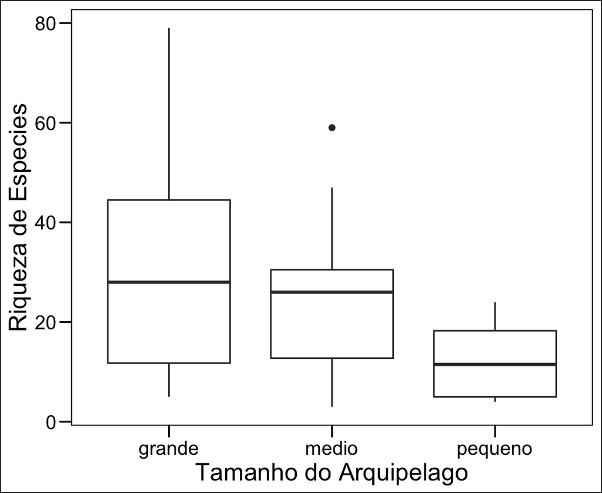

- Caso você queira ordenar os níveis desses fatores de uma forma diferente, podemos utilizar a função `fct_relevel` do pacote `forcats` do `tidyverse`.

```r
ilhas <- ilhas %>%
  mutate(arquipelago = fct_relevel(.f = arquipelago, "pequeno", "medio"))
```

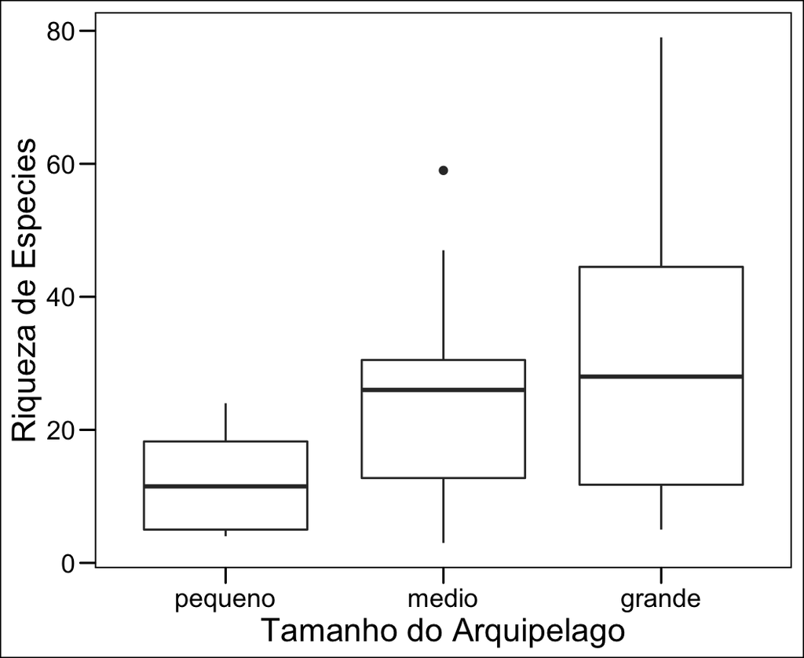

- Isto pode ser útil para a criação de figuras, como no exemplo acima, mas também quando você for fazer suas análises estatísticas.